# BIS 15L Midterm 2

```r
library(tidyverse)
library(janitor)
library(here)
library(naniar)
```

## Instructions

Answer the following questions and complete the exercises in RMarkdown. Please embed all of your code and push your final work to your repository. Your code should be organized, clean, and run free from errors. Be sure to **add your name** to the author header above. You may use any resources to answer these questions (including each other), but you may not post questions to Open Stacks or external help sites. There are 10 total questions.

Make sure to use the formatting conventions of RMarkdown to make your report neat and clean! Your plots should use consistent aesthetics throughout.

This exam is due by **12:00p on Tuesday, February 22**.

## Gapminder

For this assignment, we are going to use data from [gapminder](https://www.gapminder.org/). Gapminder includes information about economics, population, social issues, and life expectancy from countries all over the world. We will use three data sets, so please load all three as separate objects.

1. population_total.csv
2. income_per_person_gdppercapita_ppp_inflation_adjusted.csv
3. life_expectancy_years.csv

```r
population_total <- readr::read_csv("data/population_total.csv")
glimpse(population_total)
```

```
## Rows: 195
## Columns: 302
## $ country <chr> "Afghanistan", "Albania", "Algeria", "Andorra", "Angola", "Ant…
## $ `1800`  <dbl> 3280000, 400000, 2500000, 2650, 1570000, 37000, 534000, 413000…
## $ `1801`  <dbl> 3280000, 402000, 2510000, 2650, 1570000, 37000, 520000, 413000…
## $ `1802`  <dbl> 3280000, 404000, 2520000, 2650, 1570000, 37000, 506000, 413000…
## $ `1803`  <dbl> 3280000, 405000, 2530000, 2650, 1570000, 37000, 492000, 413000…
## $ `1804`  <dbl> 3280000, 407000, 2540000, 2650, 1570000, 37000, 479000, 413000…
## $ `1805`  <dbl> 3280000, 409000, 2550000, 2650, 1570000, 37000, 466000, 413000…
## $ `1806`  <dbl> 3280000, 411000, 2560000, 2650, 1570000, 37000, 453000, 413000…
## $ `1807`  <dbl> 3280000, 413000, 2560000, 2650, 1570000, 37000, 441000, 413000…
## $ `1808`  <dbl> 3280000, 414000, 2570000, 2650, 1570000, 37000, 429000, 413000…
## $ `1809`  <dbl> 3280000, 416000, 2580000, 2650, 1570000, 37000, 417000, 413000…
## $ `1810`  <dbl> 3280000, 418000, 2590000, 2650, 1570000, 37000, 420000, 413000…
## $ `1811`  <dbl> 3280000, 420000, 2600000, 2650, 1570000, 37000, 422000, 413000…
```

[output cut: 289 more lines]

```r
income_per <- readr::read_csv("data/income_per_person_gdppercapita_ppp_inflation_adjusted.csv")
glimpse(income_per)
```

```
## Rows: 193
## Columns: 242
## $ country <chr> "Afghanistan", "Albania", "Algeria", "Andorra", "Angola", "Ant…
## $ `1800`  <dbl> 603, 667, 715, 1200, 618, 757, 1640, 514, 817, 1850, 775, 1450…
## $ `1801`  <dbl> 603, 667, 716, 1200, 620, 757, 1640, 514, 822, 1850, 775, 1450…
## $ `1802`  <dbl> 603, 667, 717, 1200, 623, 757, 1650, 514, 826, 1860, 775, 1450…
## $ `1803`  <dbl> 603, 667, 718, 1200, 626, 757, 1650, 514, 831, 1870, 775, 1450…
## $ `1804`  <dbl> 603, 667, 719, 1210, 628, 757, 1660, 514, 836, 1880, 775, 1450…
## $ `1805`  <dbl> 603, 668, 720, 1210, 631, 757, 1660, 514, 841, 1880, 776, 1450…
## $ `1806`  <dbl> 603, 668, 721, 1210, 634, 757, 1670, 514, 845, 1890, 776, 1450…
## $ `1807`  <dbl> 603, 668, 722, 1210, 637, 758, 1680, 514, 850, 1900, 776, 1450…
## $ `1808`  <dbl> 603, 668, 723, 1220, 640, 758, 1680, 514, 855, 1910, 776, 1450…
## $ `1809`  <dbl> 603, 668, 724, 1220, 642, 758, 1690, 514, 860, 1920, 776, 1450…
## $ `1810`  <dbl> 604, 668, 725, 1220, 645, 758, 1690, 514, 865, 1920, 777, 1450…
## $ `1811`  <dbl> 604, 668, 726, 1220, 648, 758, 1700, 515, 869, 1940, 777, 1450…
```

[output cut: 229 more lines]

```r
life_expectancy <- readr::read_csv("data/life_expectancy_years.csv")
glimpse(life_expectancy)
```

```
## Rows: 187
## Columns: 302
## $ country <chr> "Afghanistan", "Albania", "Algeria", "Andorra", "Angola", "Ant…
## $ `1800`  <dbl> 28.2, 35.4, 28.8, NA, 27.0, 33.5, 33.2, 34.0, 34.0, 34.4, 29.2…
## $ `1801`  <dbl> 28.2, 35.4, 28.8, NA, 27.0, 33.5, 33.2, 34.0, 34.0, 34.4, 29.2…
## $ `1802`  <dbl> 28.2, 35.4, 28.8, NA, 27.0, 33.5, 33.2, 34.0, 34.0, 34.4, 29.2…
## $ `1803`  <dbl> 28.2, 35.4, 28.8, NA, 27.0, 33.5, 33.2, 34.0, 34.0, 34.4, 29.2…
## $ `1804`  <dbl> 28.2, 35.4, 28.8, NA, 27.0, 33.5, 33.2, 34.0, 34.0, 34.4, 29.2…
## $ `1805`  <dbl> 28.2, 35.4, 28.8, NA, 27.0, 33.5, 33.2, 34.0, 34.0, 34.4, 29.2…
## $ `1806`  <dbl> 28.1, 35.4, 28.8, NA, 27.0, 33.5, 33.2, 34.0, 34.0, 34.4, 29.2…
## $ `1807`  <dbl> 28.1, 35.4, 28.8, NA, 27.0, 33.5, 33.2, 34.0, 34.0, 34.4, 29.2…
## $ `1808`  <dbl> 28.1, 35.4, 28.8, NA, 27.0, 33.5, 33.2, 34.0, 34.0, 34.4, 29.2…
## $ `1809`  <dbl> 28.1, 35.4, 28.8, NA, 27.0, 33.5, 33.2, 34.0, 34.0, 34.4, 29.2…
## $ `1810`  <dbl> 28.1, 35.4, 28.8, NA, 27.0, 33.5, 33.2, 34.0, 34.0, 34.4, 29.2…
## $ `1811`  <dbl> 28.1, 35.4, 28.8, NA, 27.0, 33.5, 33.2, 34.0, 34.0, 34.4, 29.2…
```

[output cut: 289 more lines]

1. (3 points) Once you have an idea of the structure of the data, please make each data set tidy (hint: think back to pivots) and store them as new objects. You will need both the original (wide) and tidy (long) data!

```r
population_long <- population_total %>%
   pivot_longer(-country,names_to="year", values_to="population_tot", values_drop_na = TRUE)
```

```r
income_long <- income_per %>%
   pivot_longer(-country,names_to="year", values_to="income_per_person", values_drop_na = TRUE)
```

```r
life_long <- life_expectancy %>%
   pivot_longer(-country,names_to="year", values_to="life_expect", values_drop_na = TRUE)
life_long
```

```
## # A tibble: 55,528 × 3
##    country     year  life_expect
##    <chr>       <chr>       <dbl>
##  1 Afghanistan 1800         28.2
##  2 Afghanistan 1801         28.2
##  3 Afghanistan 1802         28.2
##  4 Afghanistan 1803         28.2
##  5 Afghanistan 1804         28.2
##  6 Afghanistan 1805         28.2
##  7 Afghanistan 1806         28.1
##  8 Afghanistan 1807         28.1
##  9 Afghanistan 1808         28.1
## 10 Afghanistan 1809         28.1
## # … with 55,518 more rows
```

2. (1 point) How many different countries are represented in the data? Provide the total number and their names. Since each data set includes different numbers of countries, you will need to do this for each one.

```r
population_total %>%
  summarise(country)
```

```
## # A tibble: 195 × 1
##    country
##    <chr>
##  1 Afghanistan
##  2 Albania
##  3 Algeria
##  4 Andorra
##  5 Angola
##  6 Antigua and Barbuda
##  7 Argentina
##  8 Armenia
##  9 Australia
## 10 Austria
## # … with 185 more rows
```

For our population total data, all the countries are listed here and as it says there are 195 total countries. u

```r
life_expectancy %>%
  summarise(country)
```

```
## # A tibble: 187 × 1
##    country
##    <chr>
##  1 Afghanistan
##  2 Albania
##  3 Algeria
##  4 Andorra
##  5 Angola
##  6 Antigua and Barbuda
##  7 Argentina
##  8 Armenia
##  9 Australia
## 10 Austria
## # … with 177 more rows
```

In the life expectancy data, there was a total of 187 countries and they are all listed above as well.

```r
income_per %>%
  summarise(country)
```

```
## # A tibble: 193 × 1
##    country
##    <chr>
##  1 Afghanistan
##  2 Albania
##  3 Algeria
##  4 Andorra
##  5 Angola
##  6 Antigua and Barbuda
##  7 Argentina
##  8 Armenia
##  9 Australia
## 10 Austria
## # … with 183 more rows
```

For the income per person data, 193 total countries listed above as well.

## Life Expectancy

3. (2 points) Let’s limit the data to 100 years (1920-2020). For these years, which country has the highest average life expectancy? How about the lowest average life expectancy?

```r
life_long %>%
  filter(between(year, 1920, 2020)) %>%
  group_by(country) %>%
  summarise(average=mean(life_expect, na.rm=T)) %>%
  arrange(desc(average))
```

```
## # A tibble: 187 × 2
##    country     average
##    <chr>         <dbl>
##  1 Andorra        79.8
##  2 Sweden         73.5
##  3 Norway         73.2
##  4 Netherlands    73.0
##  5 Dominica       73.0
##  6 Iceland        72.9
##  7 Australia      72.7
##  8 Switzerland    72.7
##  9 Denmark        71.9
## 10 Canada         71.8
## # … with 177 more rows
```

Here we can see from 1920-2020 the country with the highest life expectancy average is Andorra with 79.77.

```r
life_long %>%
  filter(between(year, 1920, 2020)) %>%
  group_by(country) %>%
  summarise(average=mean(life_expect, na.rm=T)) %>%
  arrange(average)
```

```
## # A tibble: 187 × 2
##    country                  average
##    <chr>                      <dbl>
##  1 Central African Republic    41.8
##  2 Mali                        41.8
##  3 Ethiopia                    42.6
##  4 Sierra Leone                42.6
##  5 Guinea-Bissau               42.6
##  6 Burundi                     42.8
##  7 Malawi                      42.8
##  8 Uganda                      43.3
##  9 Eritrea                     43.4
## 10 Yemen                       43.6
## # … with 177 more rows
```

Here we can see the country with the lowest average life expectancy is Central African Republic with an age of 41.77.

4. (3 points) Although we can see which country has the highest life expectancy for the past 100 years, we don’t know which countries have changed the most. What are the top 5 countries that have experienced the biggest improvement in life expectancy between 1920-2020?

```r
life_wide <- life_long %>%
  filter(between(year, 1920, 2020)) %>%
  pivot_wider(names_from=year,values_from=life_expect)
life_wide
```

```
## # A tibble: 187 × 102
##    country `1920` `1921` `1922` `1923` `1924` `1925` `1926` `1927` `1928` `1929`
##    <chr>    <dbl>  <dbl>  <dbl>  <dbl>  <dbl>  <dbl>  <dbl>  <dbl>  <dbl>  <dbl>
##  1 Afghan…   30.6   30.7   30.8   30.8   30.9   31     31     31.1   31.1   31.2
##  2 Albania   35.4   35.4   35.4   35.4   35.4   35.4   35.4   35.4   35.4   35.4
##  3 Algeria   29.6   29.6   29.4   32     33.5   34.3   33.6   28.8   32.4   32.7
##  4 Andorra   NA     NA     NA     NA     NA     NA     NA     NA     NA     NA
##  5 Angola    30.4   30.5   30.6   30.6   30.7   30.8   30.8   30.9   31     31
##  6 Antigu…   33.9   33.9   34.8   35.6   36.4   37.3   38.1   39     39.8   40.7
##  7 Argent…   49.9   50.3   50.8   51.3   51.7   52.2   52.5   52.9   53.2   53.5
##  8 Armenia   27     36.7   37.6   38.4   40.8   39.9   42.9   42.3   43.7   42.5
##  9 Austra…   60.6   61.1   63     61.8   62.6   63.3   63.1   63     63.1   63.3
## 10 Austria   50.3   50.9   51.4   52     52.6   53.1   53.7   54.3   54.9   55.4
## # … with 177 more rows, and 91 more variables: `1930` <dbl>, `1931` <dbl>,
## #   `1932` <dbl>, `1933` <dbl>, `1934` <dbl>, `1935` <dbl>, `1936` <dbl>,
## #   `1937` <dbl>, `1938` <dbl>, `1939` <dbl>, `1940` <dbl>, `1941` <dbl>,
## #   `1942` <dbl>, `1943` <dbl>, `1944` <dbl>, `1945` <dbl>, `1946` <dbl>,
## #   `1947` <dbl>, `1948` <dbl>, `1949` <dbl>, `1950` <dbl>, `1951` <dbl>,
## #   `1952` <dbl>, `1953` <dbl>, `1954` <dbl>, `1955` <dbl>, `1956` <dbl>,
## #   `1957` <dbl>, `1958` <dbl>, `1959` <dbl>, `1960` <dbl>, `1961` <dbl>, …
```

```r
life_diff <- life_wide %>%
  mutate(diff=`2020`-`1920`) %>%
  select(country, diff) %>%
  arrange(desc(diff))
```

5. (3 points) Make a plot that shows the change over the past 100 years for the country with the biggest improvement in life expectancy. Be sure to add appropriate aesthetics to make the plot clean and clear. Once you have made the plot, do a little internet searching and see if you can discover what histodrical event may have contributed to this remarkable change.

```r
kuwait <- life_long %>%
  filter(country == "Kuwait", 1919<year, year<2021)
kuwait
```

```
## # A tibble: 101 × 3
##    country year  life_expect
##    <chr>   <chr>       <dbl>
##  1 Kuwait  1920         26.6
##  2 Kuwait  1921         26.6
##  3 Kuwait  1922         26.6
##  4 Kuwait  1923         26.6
##  5 Kuwait  1924         26.7
##  6 Kuwait  1925         26.7
##  7 Kuwait  1926         26.7
##  8 Kuwait  1927         26.7
##  9 Kuwait  1928         26.7
## 10 Kuwait  1929         26.7
## # … with 91 more rows
```

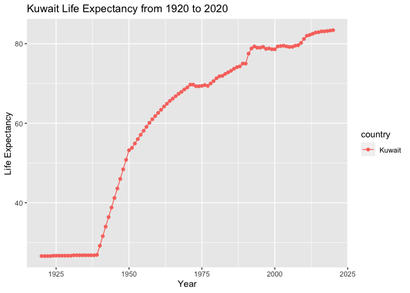

```r
kuwait%>%
  ggplot(aes(x=as.numeric(year),y=life_expect, group=country, color=country))+geom_point()+geom_line()+labs(title="Kuwait Life Expectancy from 1920 to 2020", x="Year", y="Life Expectancy")
```

Here we can see there is a huge jump in life expectancy after around the years 1940-1950. When researching, I found that in the 1930s, Kuwait started getting into the petroleum industry. This brought lots of wealth and economic growth which allowed their life expectancy to grow much longer.

## Population Growth

6. (3 points) Which 5 countries have had the highest population growth over the past 100 years (1920-2020)?

```r
population_long %>%
  group_by(country) %>%
  filter(1919<year,year<2021) %>%
  summarise(population_growth=(max(population_tot)-min(population_tot))) %>%
  arrange(desc(population_growth)) %>%
  head(n=5)
```

```
## # A tibble: 5 × 2
##   country       population_growth
##   <chr>                     <dbl>
## 1 India                1063000000
## 2 China                 968000000
## 3 Indonesia             226700000
## 4 United States         220000000
## 5 Pakistan              199300000
```

Here we can see that the top contries in the past 100 years for population growth were India, China, Indonesia, USA, and Pakistan. 7. (4 points) Produce a plot that shows the 5 countries that have had the highest population growth over the past 100 years (1920-2020). Which countries appear to have had exponential growth?

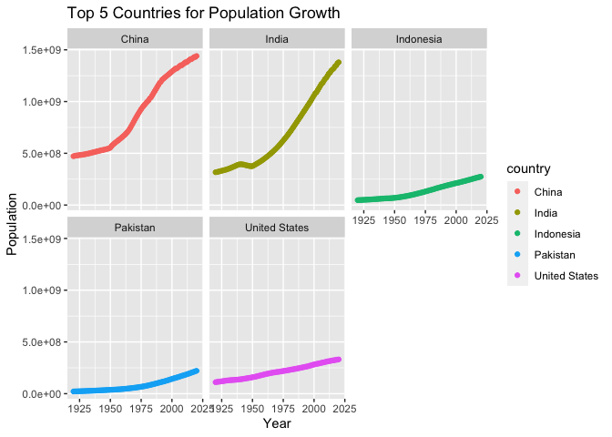

```r
population_long %>%
  filter(year<2021, year>1919, country == "India"|country == "China"|country == "Indonesia"|country == "United States"|country == "Pakistan")%>%
  ggplot(aes(x=as.numeric(year), y=population_tot, color=country)) + geom_point() + facet_wrap(~country)+
  labs(title = "Top 5 Countries for Population Growth", x = "Year", y = "Population")
```

It seems like both China and India have exponential growth for population.

## Income

The units used for income are gross domestic product per person adjusted for differences in purchasing power in international dollars.

8. (4 points) As in the previous questions, which countries have experienced the biggest growth in per person GDP. Show this as a table and then plot the changes for the top 5 countries. With a bit of research, you should be able to explain the dramatic downturns of the wealthiest economies that occurred during the 1980’s.  
   notes:
- prepare change in GDP
- up to us

```r
income_per%>%
  select("country", "1920", "2020") %>%
  mutate(diff_income = `2020` - `1920`) %>%
  arrange(desc(diff_income)) %>%
  head(n=5)
```

```
## # A tibble: 5 × 4
##   country    `1920` `2020` diff_income
##   <chr>       <dbl>  <dbl>       <dbl>
## 1 Qatar        2300 116000      113700
## 2 Luxembourg   5730  95100       89370
## 3 Singapore    2440  90500       88060
## 4 Brunei       2130  75100       72970
## 5 Ireland      5170  74100       68930
```

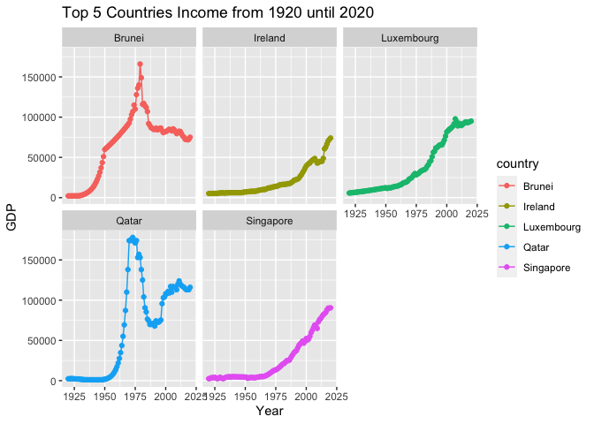

```r
income_long%>%
   filter(country %in% c("Qatar", "Luxembourg", "Singapore", "Brunei", "Ireland"),between(year,1920,2020))%>%
  ggplot(aes(x=as.numeric(year), y=income_per_person,  group=country,color=country))+geom_point()+geom_line()+facet_wrap(~country) + labs(title="Top 5 Countries Income from 1920 until 2020", x="Year", y="GDP")
```

9. (3 points) Create three new objects that restrict each data set (life expectancy, population, income) to the years 1920-2020. Hint: I suggest doing this with the long form of your data. Once this is done, merge all three data sets using the code I provide below. You may need to adjust the code depending on how you have named your objects. I called mine `life_expectancy_100`, `population_100`, and `income_100`. For some of you, learning these `joins` will be important for your project.

```r
life_long_100 <- life_long %>%
  filter(year>="1920" & year<="2020")
population_long_100 <- population_long %>%
  filter(year>="1920" & year<="2020")
income_long_100 <- income_long %>%
  filter(year>="1920" & year<="2020")
```

```r
gapminder_join <- inner_join(life_long_100, population_long_100, by= c("country", "year"))
gapminder_join <- inner_join(gapminder_join, income_long_100, by= c("country", "year"))
gapminder_join
```

```
## # A tibble: 18,728 × 5
##    country     year  life_expect population_tot income_per_person
##    <chr>       <chr>       <dbl>          <dbl>             <dbl>
##  1 Afghanistan 1920         30.6       10600000              1490
##  2 Afghanistan 1921         30.7       10500000              1520
##  3 Afghanistan 1922         30.8       10300000              1550
##  4 Afghanistan 1923         30.8        9710000              1570
##  5 Afghanistan 1924         30.9        9200000              1600
##  6 Afghanistan 1925         31          8720000              1630
##  7 Afghanistan 1926         31          8260000              1650
##  8 Afghanistan 1927         31.1        7830000              1680
##  9 Afghanistan 1928         31.1        7420000              1710
## 10 Afghanistan 1929         31.2        7100000              1740
## # … with 18,718 more rows
```

10. (4 points) Use the joined data to perform an analysis of your choice. The analysis should include a comparison between two or more of the variables `life_expectancy`, `population`, or `income.`

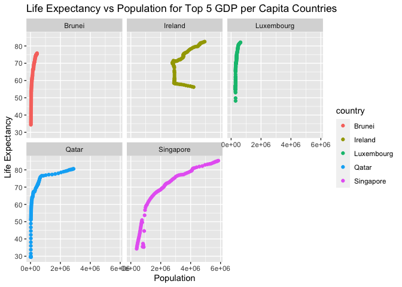

```r
gapminder_join%>%
  filter(country %in% c("Qatar", "Luxembourg", "Singapore", "Brunei", "Ireland"))%>%
  ggplot(aes(x=population_tot, y=life_expect, group=country, color=country)) + geom_point()+facet_wrap(~country)+ labs(title="Life Expectancy vs Population for Top 5 GDP per Capita Countries", x="Population", y="Life Expectancy")
```

For this question, I chose to compare life expectancy and population for the five countries that I found before had the top GDP per capita.